# Exploratory Analysis of Step Data

2024-05-09

```r
suppressMessages({
        suppressWarnings(
        {
                library(dplyr)
                library(ggplot2)
                library(cowplot)
        })
})
```

## Part 1: Load and preprocess the data.

### 1. Load data

```r
data <- read.csv('activity.csv')
head(data)
```

```
##   steps       date interval
## 1    NA 2012-10-01        0
## 2    NA 2012-10-01        5
## 3    NA 2012-10-01       10
## 4    NA 2012-10-01       15
## 5    NA 2012-10-01       20
## 6    NA 2012-10-01       25
```

## Part 2: What is mean total number of steps taken per day?

### A. Calculate the total number of steps taken per day.

```r
sum_data <- data %>% group_by(date) %>% summarize(Sum_Steps =
                                                          sum(steps, na.rm=TRUE))
```

### B. Make a histogram of the total number of steps taken each day.

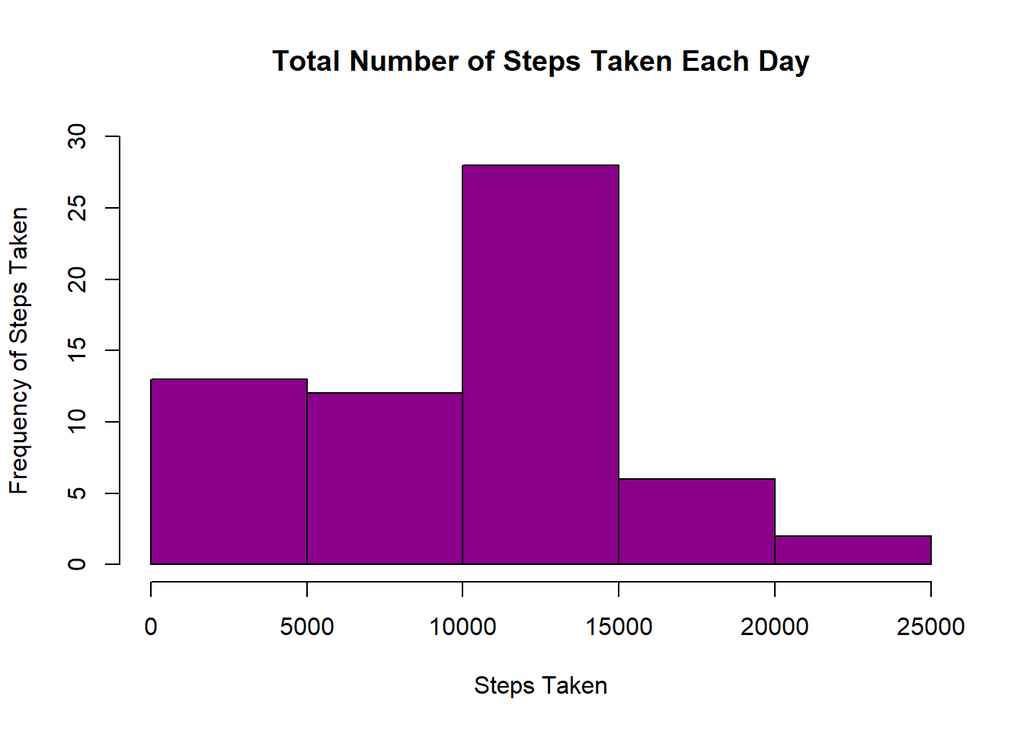

```r
hist(sum_data$Sum_Steps,
     main="Total Number of Steps Taken Each Day",
     xlab="Steps Taken",
     ylab='Frequency of Steps Taken',
     ylim=c(0, 30),
     col="darkmagenta"
     )
```

### C. Calculate the mean and median of the total of steps taken per day.

```r
mean <- mean(sum_data$Sum_Steps, na.rm = TRUE)
median <- median(sum_data$Sum_Steps, na.rm = TRUE)
print(paste('Mean of total of steps taken per day is', mean))
```

```
## [1] "Mean of total of steps taken per day is 9354.22950819672"
```

```r
print(paste('Median of total of steps taken per day is', median))
```

```
## [1] "Median of total of steps taken per day is 10395"
```

## Part 3: What is the average daily activity pattern?

### A. Make a time series plot of the 5-minute interval (x-axis) and

### the average number of steps taken, averaged across all days.

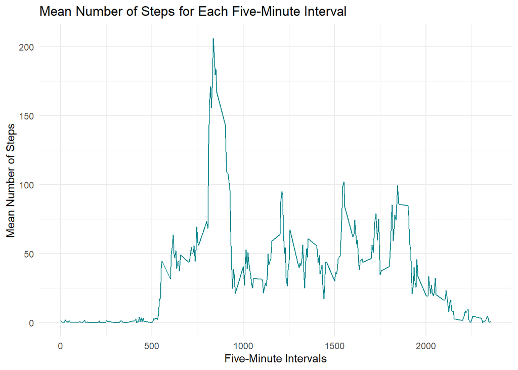

```r
interval_data <- data %>% group_by(interval) %>%
        summarize(Mean_Interval = mean(steps, na.rm=TRUE))

p <- ggplot(interval_data, aes(x=interval, y=Mean_Interval)) +
            geom_line(color="turquoise4") + theme_minimal() +
            labs(x="Five-Minute Intervals",
                 y="Mean Number of Steps",
                 title="Mean Number of Steps for Each Five-Minute Interval")
print(p)
```

```r
max <- max(interval_data$Mean_Interval, na.rm = TRUE)
print(paste('Max of mean of total of steps taken each five-minute interval is'
            , max))
```

```
## [1] "Max of mean of total of steps taken each five-minute interval is 206.169811320755"
```

## Part 4: Imputing missing values

```r
frac_missing <- sum(is.na(data$steps))  / length(data$steps)
print(paste('Proportion of missing values is', frac_missing))
```

```
## [1] "Proportion of missing values is 0.131147540983607"
```

### B. Devise a strategy for filling in all of the missing values in the data set.

Missing values don’t seem to be randomly distributed, and without more information about why they are missing,  
removing entries with missing values seems to be the best approach. So my approach is to locate rows with missing values, and delete them.

```r
new_data <- data[complete.cases(data), ]
head(new_data)
```

```
##     steps       date interval
## 289     0 2012-10-02        0
## 290     0 2012-10-02        5
## 291     0 2012-10-02       10
## 292     0 2012-10-02       15
## 293     0 2012-10-02       20
## 294     0 2012-10-02       25
```

### D. Make a histogram of the total number of steps taken each day.

#### Calculate total number of steps

```r
new_sum_data <- new_data %>% group_by(date) %>%
                summarize(Sum_Steps = sum(steps, na.rm=TRUE))
head(new_sum_data)
```

```
## # A tibble: 6 × 2
##   date       Sum_Steps
##   <chr>          <int>
## 1 2012-10-02       126
## 2 2012-10-03     11352
## 3 2012-10-04     12116
## 4 2012-10-05     13294
## 5 2012-10-06     15420
## 6 2012-10-07     11015
```

#### Plot histogram

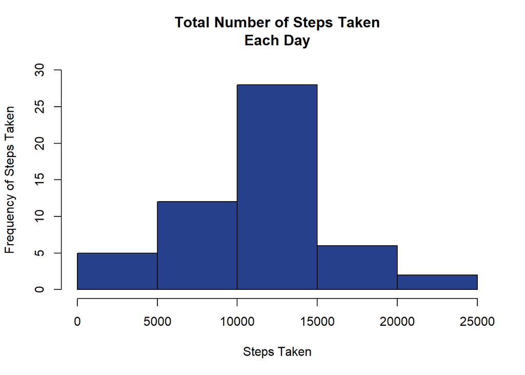

```r
hist(new_sum_data$Sum_Steps,
     main="Total Number of Steps Taken\nEach Day",
     xlab="Steps Taken",
     ylab='Frequency of Steps Taken',
     ylim=c(0, 30),
     col="royalblue4"
)
```

## E. Calculate and report the mean and median total number of steps taken per day.

```r
new_mean <- mean(new_sum_data$Sum_Steps, na.rm = TRUE)
new_median <- median(new_sum_data$Sum_Steps, na.rm = TRUE)
print(paste('Mean of total of steps taken per day is', new_mean))
```

```
## [1] "Mean of total of steps taken per day is 10766.1886792453"
```

```r
print(paste('Median of total of steps taken per day is', new_median))
```

```
## [1] "Median of total of steps taken per day is 10765"
```

## F. What is the impact of imputing missing data on the estimates?

```r
perc_mean_diff <- (mean - new_mean) / mean(mean, new_mean) * 100
print(paste('The percent difference between the first mean and the second is ',
            perc_mean_diff, '%', sep=''))
```

```
## [1] "The percent difference between the first mean and the second is -15.0943396226415%"
```

```r
perc_median_diff <- (median - new_median) / mean(median, new_median) * 100
print(paste('The percent difference between the first median and the second is ',
            perc_median_diff, '%', sep=''))
```

```
## [1] "The percent difference between the first median and the second is -3.55940355940356%"
```

## Part 5: Are there differences in activity between weekdays and weekends?

### A. Create a new factor variable for “weekday” and “weekend”.

#### Convert date column to POSIXlt class

```r
new_data$day <- strftime(new_data$date, "%A")
```

#### Find weekend values

```r
weekend <- c('Sunday', 'Saturday')
```

#### Create mask to find weekend days

```r
mask <- new_data$day %in% weekend
```

#### Create factor column ‘day_category’

```r
new_data$day_category <- factor(mask,
                                levels=c(FALSE, TRUE),
                                labels = c("weekday", "weekend"))
head(new_data)
```

```
##     steps       date interval     day day_category
## 289     0 2012-10-02        0 Tuesday      weekday
## 290     0 2012-10-02        5 Tuesday      weekday
## 291     0 2012-10-02       10 Tuesday      weekday
## 292     0 2012-10-02       15 Tuesday      weekday
## 293     0 2012-10-02       20 Tuesday      weekday
## 294     0 2012-10-02       25 Tuesday      weekday
```

### B. Make a panel plot containing a time series plot of the 5-minute interval

### and average number of steps taken, averaged across all the days.

```r
new_interval_data <- new_data %>% group_by(day_category, interval) %>%
        summarize(Mean_Interval = mean(steps))
```

#### Separate data into weekend and weekday data frames

```r
weekend_data <- new_interval_data[new_interval_data$day_category %in% c('weekend'), ]
weekday_data <- new_interval_data[new_interval_data$day_category %in% c('weekday'), ]
```

#### Create panel plot

##### Create weekday data plot

```r
p1 <- ggplot(weekday_data, aes(x=interval, y=Mean_Interval)) +
        geom_line(color="deepskyblue4") + theme_minimal() +
        labs(x="Five-Minute Intervals",
             y="Mean Number of Steps",
             title="Mean Number of Steps for Each Five-Minute Interval on Weekdays")
```

##### Create weekend data plot

```r
p2 <- ggplot(weekend_data, aes(x=interval, y=Mean_Interval)) +
        geom_line(color="darkolivegreen4") + theme_minimal() +
        labs(x="Five-Minute Intervals",
             y="Mean Number of Steps",
             title="Mean Number of Steps for Each Five-Minute Interval on Weekends")
```

##### Plot on panel

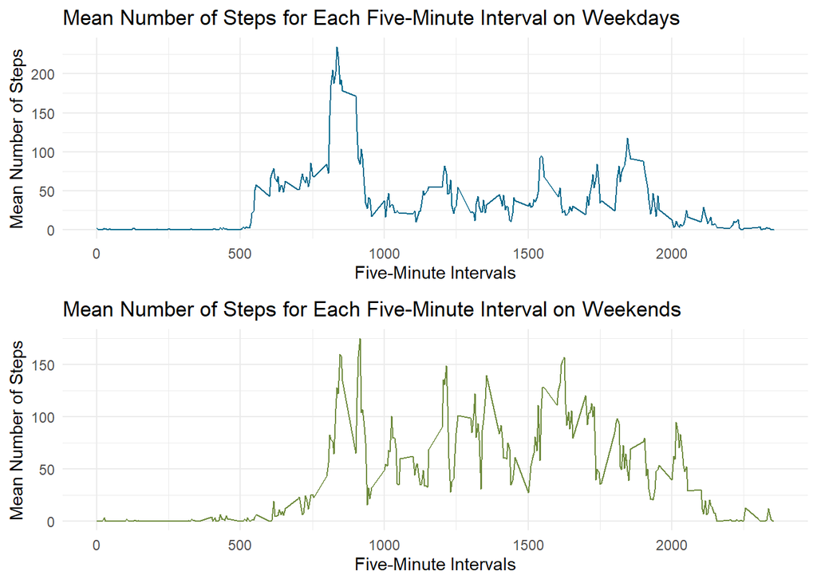

```r
plot_grid(p1, p2, ncol = 1, nrow = 2)
```